# Basic ggplot examples

Marisa Eisenberg

10/3/2017

### Load library & data set

```r
library(ggplot2)

YemenData = read.csv('Datasets/YemenCholeraOutbreak.csv')
YemenData$Date = as.Date(YemenData$Date)#, format='%m/%d/%y')
YemenData = YemenData[order(YemenData$Date),]
YemenData$Times = as.numeric(YemenData$Date-as.Date('5/22/2017', format='%m/%d/%Y'))
```

### Basic Plots

#### Notes

- `ggplot` takes dataframes as the basic object, *not* an x vector and y vector
- Once you’ve loaded the dataset, you can tell `ggplot` which variables to use for the x values, y values, color, etc. But note that ggplot won’t actually plot them until you tell it to draw soemthing!
- `geom`’s are different types of plot objects that you can add (draw) to the plot. You can set up points, lines, and other kinds of objects.
- `aes` = aesthetics, this lets you tell ggplot what information to plot and how. You can set aes either in the main `ggplot` call or within a `geom`

#### Simple Example

Let’s do a simple example:

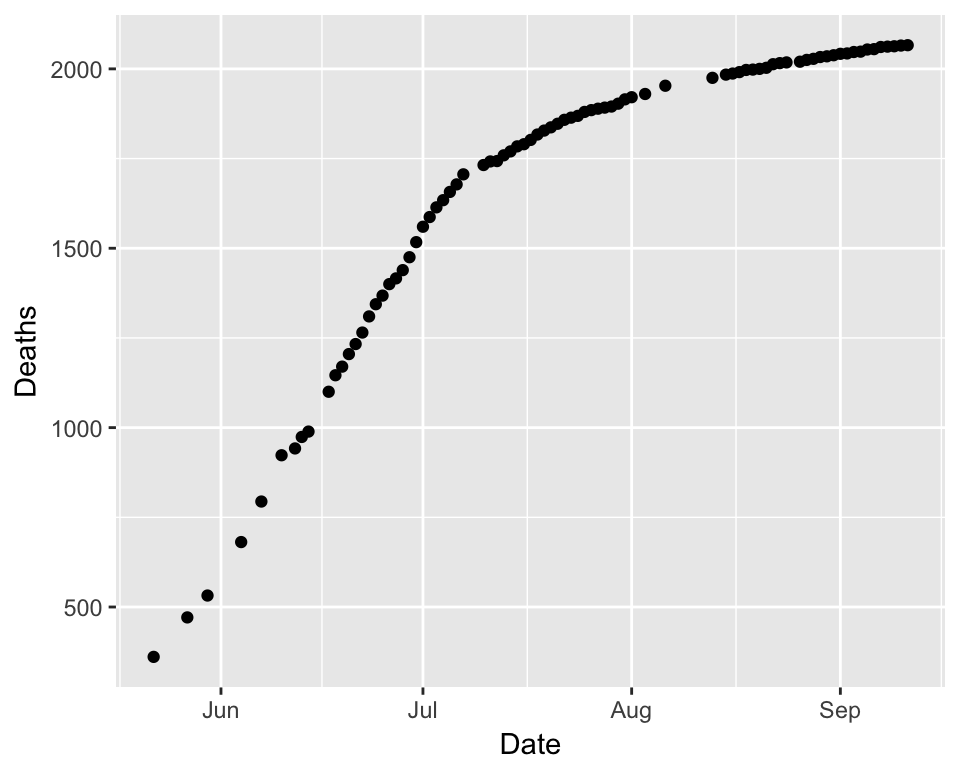

```r
# select the data  say which variables to use     draw as points
ggplot(YemenData,  aes(x=Date, y=Deaths))        + geom_point()
```

You can also add some automatic processing, like a Loess-smoothed line:

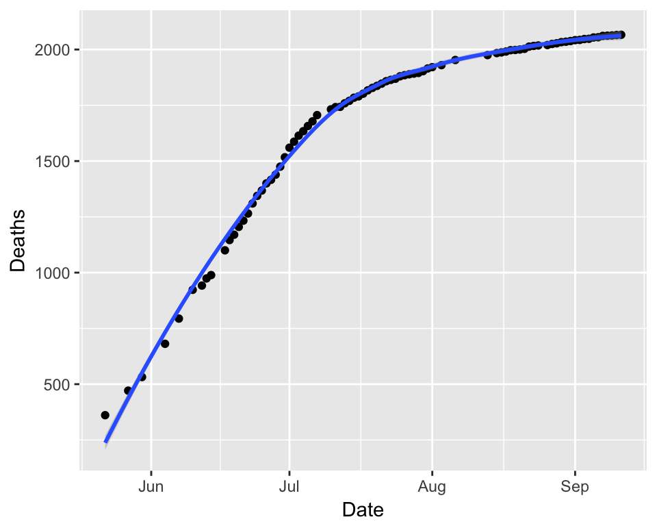

```r
ggplot(YemenData, aes(x=Date, y=Deaths)) + geom_point() + geom_smooth(method = 'loess')
```

#### Slightly fancier plots

Let’s add some more variables and specify the colors! We can also make a variable to hold the plot (in this case `yemenplot`) so we can add things later on. If we make `yemenplot` a variable, then we’ll need to use `print(yemenplot)` to display the plot at the end.

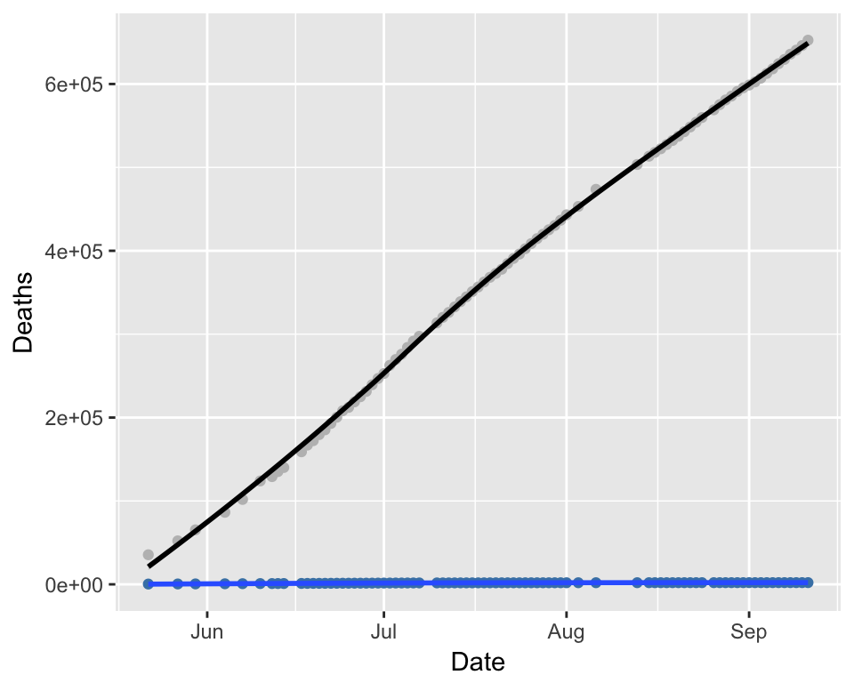

```r
yemenplot = ggplot(YemenData) +
  geom_point(aes(x=Date, y=Deaths), color = 'steelblue') +
  geom_smooth(aes(x=Date, y=Deaths), method = 'loess') +
  geom_point(aes(x=Date, y=Cases), color = 'grey') +
  geom_smooth(aes(x=Date, y=Cases), color = 'black', method = 'loess')
print(yemenplot)
```

Looks nice, but the axis labels aren’t quite right, and we let’s add a title. We’ll do that with the `labs` function:

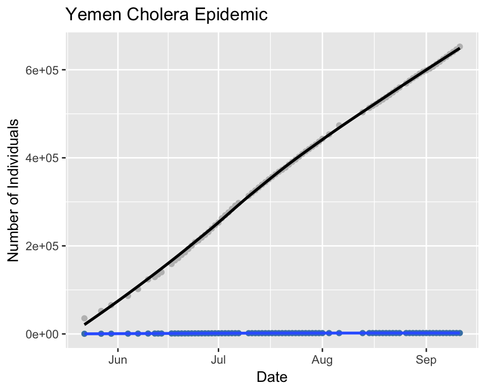

```r
yemenplot = yemenplot + labs(title="Yemen Cholera Epidemic", x="Date", y="Number of Individuals")
print(yemenplot)
```

#### Figure Legends

Now, we need a figure legend! Can make it appear automatically by defining the color in `aes`.

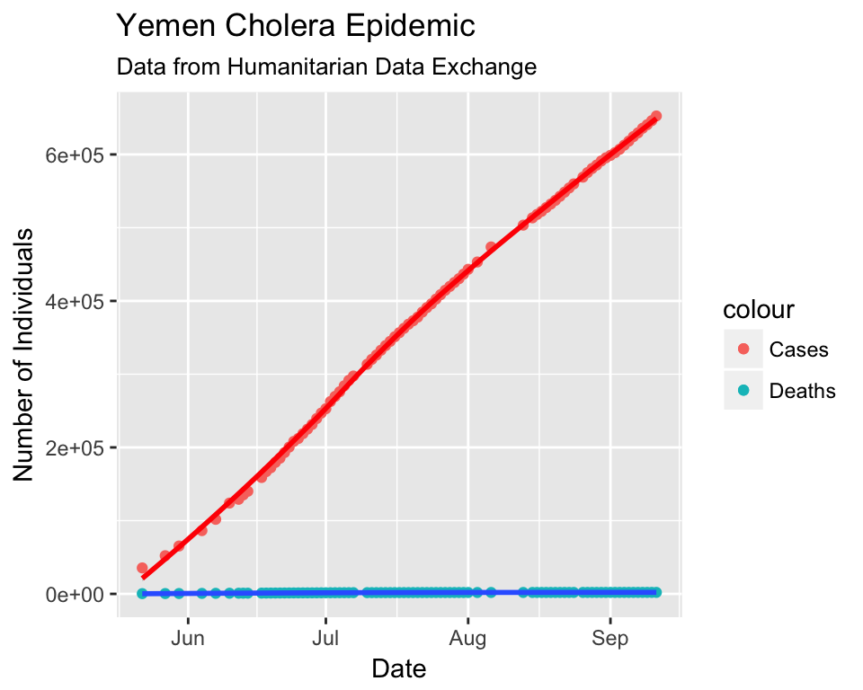

```r
yemenplot = ggplot(YemenData) +
  geom_point(aes(x=Date, y=Deaths, color = 'Deaths')) +
  geom_smooth(aes(x=Date, y=Deaths), method = 'loess') +
  geom_point(aes(x=Date, y=Cases, color = 'Cases')) +
  geom_smooth(aes(x=Date, y=Cases), color = 'red', method = 'loess') +
  labs(title="Yemen Cholera Epidemic", subtitle = "Data from Humanitarian Data Exchange", x="Date", y="Number of Individuals")
print(yemenplot)
```

But now, the legend title is “colour”. To remove the legend title or change it to something else, we can use either the `guides` or the overall figure `theme`:

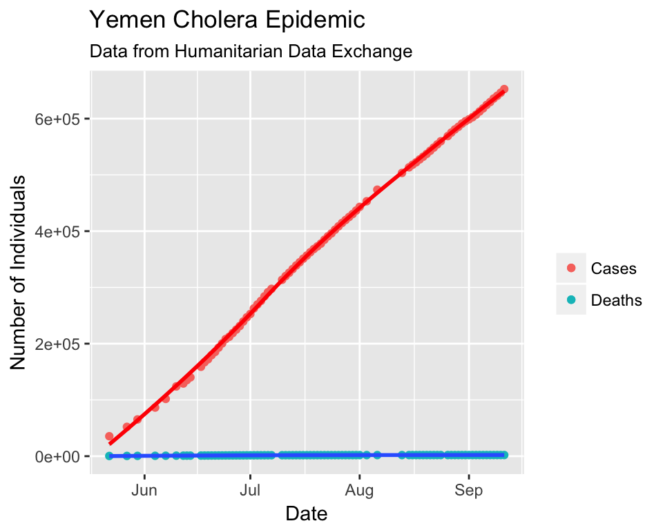

```r
yemenplot = yemenplot + guides(color = guide_legend(''))
  # theme(legend.title=element_blank())
  # guides(color = guide_legend('Legend Title!'))
print(yemenplot)
```

#### More variations

Change the color scheme:

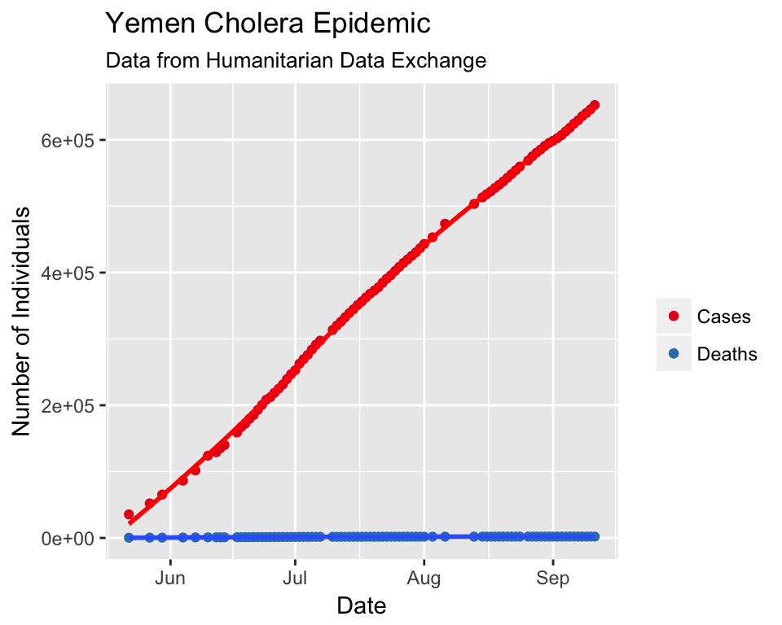

```r
yemenplot = yemenplot + scale_colour_brewer(palette = "Set1")
print(yemenplot)
```

Change the legend location:

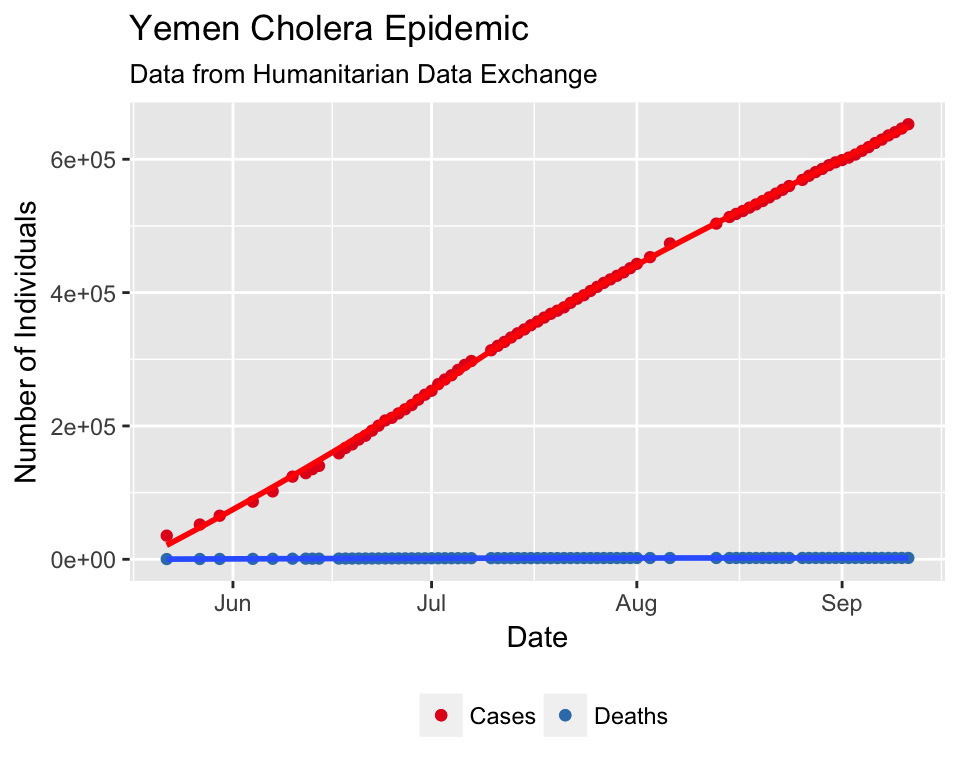

```r
yemenplot + theme(legend.position="bottom")
```

#### Changing the dot size

Make the size of the dots = the number of deaths at that time:

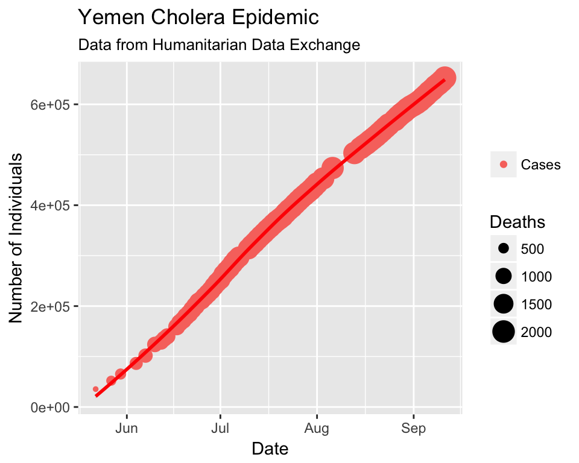

```r
yemenplot = ggplot(YemenData) +
  geom_point(aes(x=Date, y=Cases, color = 'Cases', size = Deaths)) +
  geom_smooth(aes(x=Date, y=Cases), color = 'red') +
  labs(title="Yemen Cholera Epidemic", subtitle = "Data from Humanitarian Data Exchange", x="Date", y="Number of Individuals") +
  guides(color = guide_legend(''))
print(yemenplot)
```

#### Panel Plots

We can plot multiple plots together using `grid_arrange`:

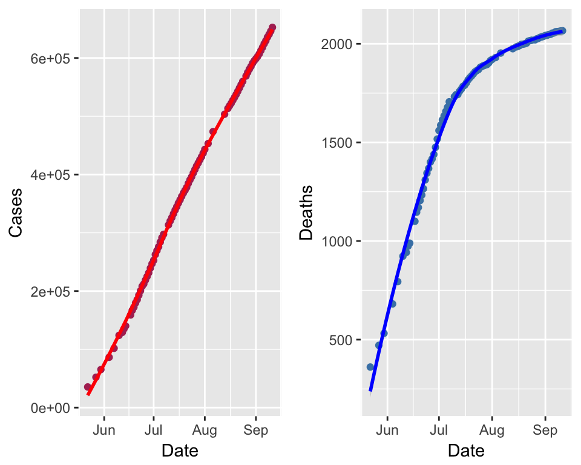

```r
library(gridExtra)

yemencases = ggplot(YemenData) +
  geom_point(aes(x=Date, y=Cases), color = 'maroon') +
  geom_smooth(aes(x=Date, y=Cases), color = 'red')
yemendeaths = ggplot(YemenData) +
  geom_point(aes(x=Date, y=Deaths), color = 'steelblue') +
  geom_smooth(aes(x=Date, y=Deaths), color = 'blue')

grid.arrange(yemencases, yemendeaths, ncol=2)
```

Or, if the panels is indicated in one of the columns, you can use `facet_wrap`:

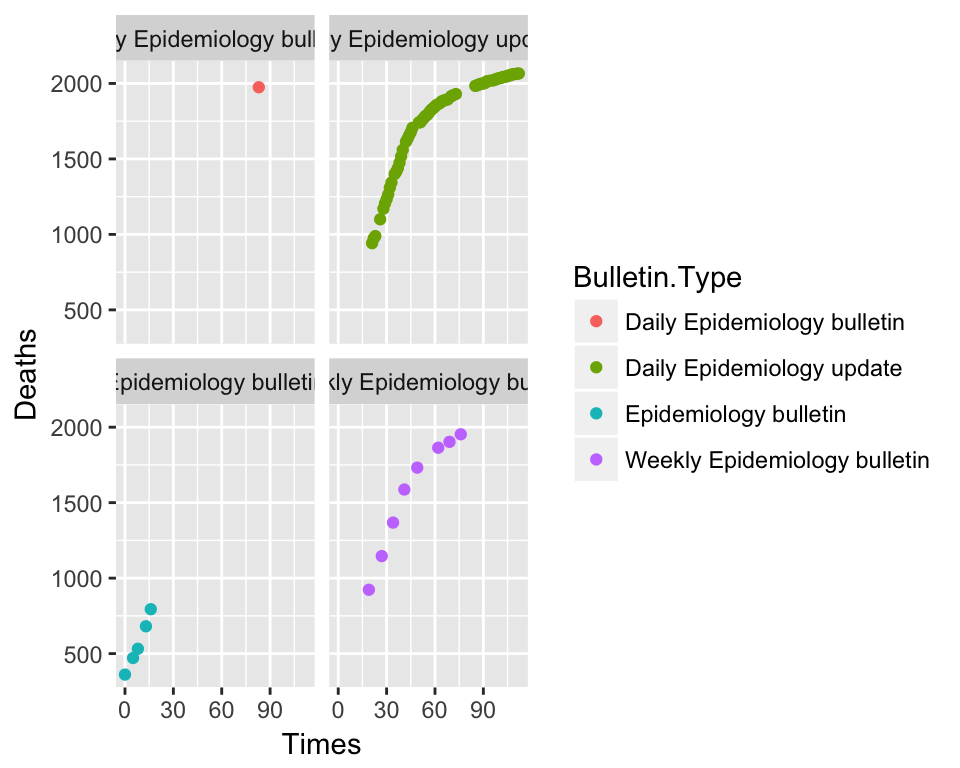

```r
facetplot = ggplot(YemenData) +
  geom_point(aes(x=Times, y=Deaths, color = Bulletin.Type)) +
  facet_wrap(~ Bulletin.Type, ncol=2)
  # labs(title="Yemen Cholera Epidemic", subtitle = "Data from Humanitarian Data Exchange", x="Time", y="Number of Individuals") +
  # theme(legend.title=element_blank())
  # guides(color = guide_legend(''))
print(facetplot)
```

`facet_grid` is similar but clears off some of the headers when you have more than one variable that you’re looking at over the panels (e.g. age categories as rows, gender as columns).

#### Saving

Lastly, to save your plot as a file, you can use `ggsave`:

```r
# Saving
ggsave("plotexample.png")  # saves the last plot
ggsave("plotexample.pdf", plot=yemenplot)  # save a specific plot
```